# 非线性模型（第二版）

# 7 广义可加模型

前面提到的模型其实都只是对简单线性回归模型的推广，如果要推广多元线性回归模型，则可以使用广义可加模型（generalized additive model，GAM）。在GAM提供的框架中，可以对每个变量用非线性的函数进行替换。

## 7.1 用于回归的GAM

对于多元回归模型
$$y_i=\beta_0+\beta_1x_{i1}+\beta_2x_{i2}+...+\beta_px_{ip}+\varepsilon_i$$
可以用$f_j(x_{ij})$替代$\beta_j x_{ij}$，模型可以改成如下形式
$$y_i=\beta_0+\sum^p_{j=1}f_j(x_{ij})+\varepsilon_i\\=\beta_0+f_1(X_{i1})+f_2(X_{i2})+...+f_p(X_{ip)}+\varepsilon_i$$
不同的非线性函数在一个模型中用加法的形式连接在一起，对于每个变量Xj都单独计算fj，fj可以是任意形式的函数，最后统一加起来用来预测y,这是GAM的一个例子，也是广义可加模型之所以叫做**可加**模型的原因。

在R中拟合这个模型有两个思路，第一个思路是把f1,f2,f3看做基函数，用最小二乘法拟合，这时可以继续使用函数lm()，但是很多函数并不能表示成基函数的形式，或者不能用最小二乘的方法进行拟合，这时GAM的思路就起到了作用，通过gam包中的gam()函数可以拟合广义可加模型。在下面的代码中，有两个点值得关注，一是提供了拟合光滑样条的函数s()（不同于普通样条bs和自然样条ns），另一个是gam对象的操作方式与lm完全一致，比如plot函数和plot.Gam函数在这里起到了完全一样的效果

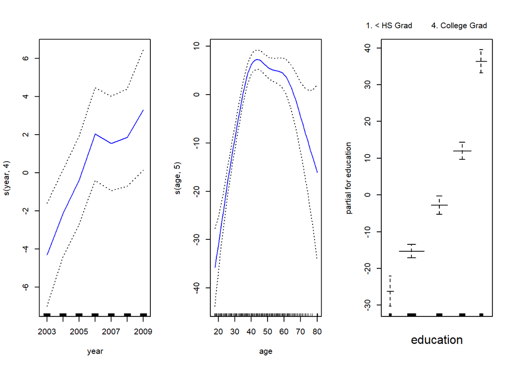

```r
gam1=lm(wage~ns(year,4)+ns(age,5)+education,data=Wage)
library(gam)
gam.m3=gam(wage~s(year,4)+s(age,5)+education,data=Wage)
par(mfrow=c(1,3))
plot(gam.m3, se=TRUE,col="blue")
```

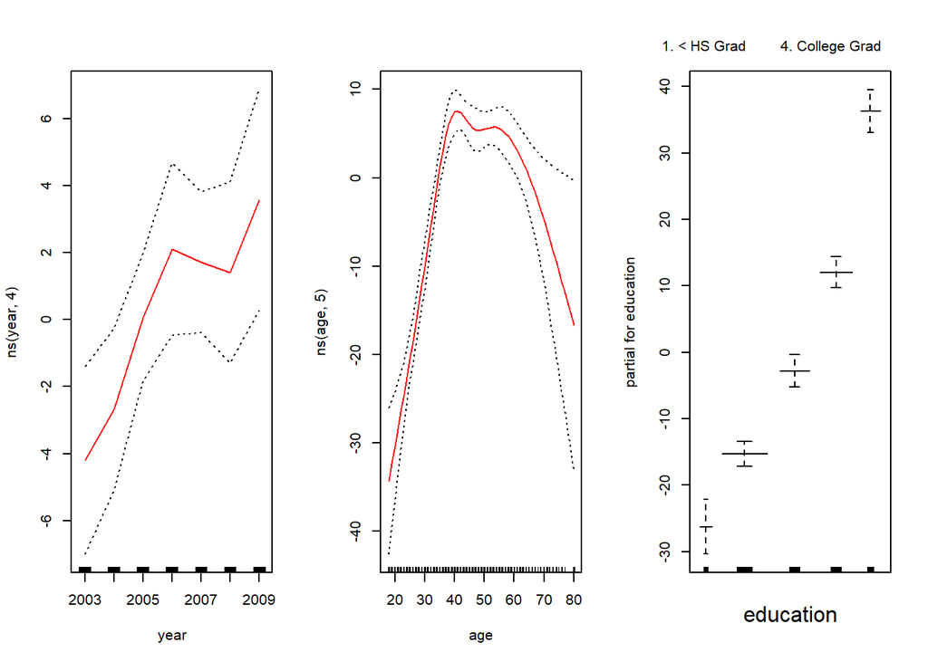

```r
plot.Gam(gam1, se=TRUE, col="red")
```

ps：部分残差，当拟合$X_3$时，是当前模型已有的残差$r_i=y_i-f_1(x_i)-f_2(x_i)$，向后拟合时，以这时的部分残差$r_i$作为响应变量拟合模型$f_3$

当然，函数选择的方式也不局限于样条，比如下图就用局部回归分析了age和wage的关系。

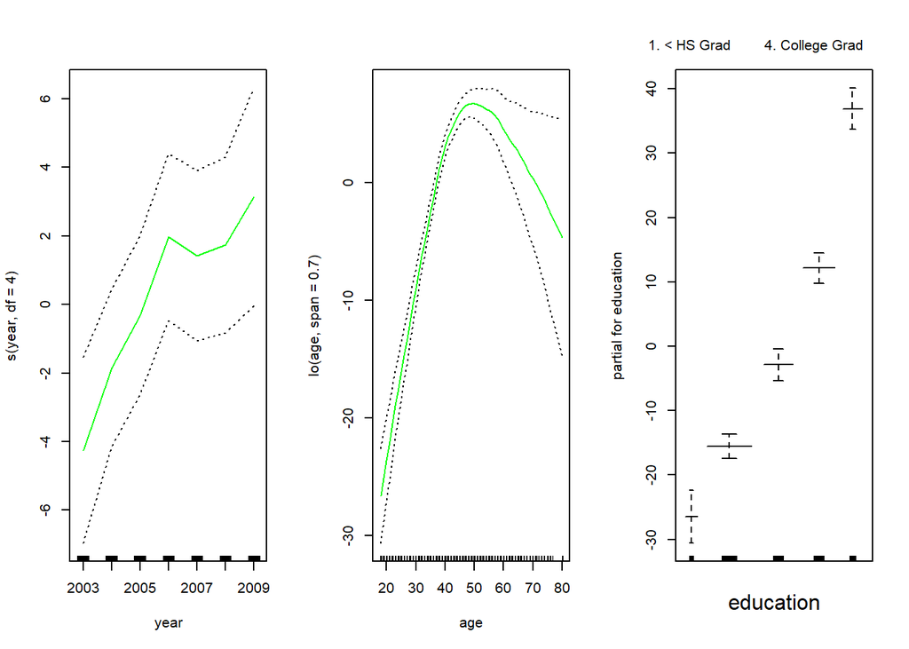

```r
par(mfrow=c(1,3))
gam.lo=gam(wage~s(year,df=4)+lo(age,span=0.7)+education,data=Wage)
plot.Gam(gam.lo, se=TRUE, col="green")
```

## 7.2 用于分类的GAM

以logistics回归为例
$$log(\frac{p(X)}{1-p(x)})=\beta_0+\beta_1X_1+\beta_2X_2+...+\beta_pX_p$$
可以转化成
$$log\bigg(\frac{p(X)}{1-p(x)}\bigg)=\beta_0+f_1(X_{1})+f_2(X_{2})+...+f_p(X_{p)}$$

用在Wage数据集中期望建立如下的模型

$$log\bigg(\frac{p(X)}{1-p(x)}\bigg)=\beta_0+\beta_1 \times year+f_2(age)+f_3(education)\\
p(X)=Pr(wage>250|year,age,education)$$

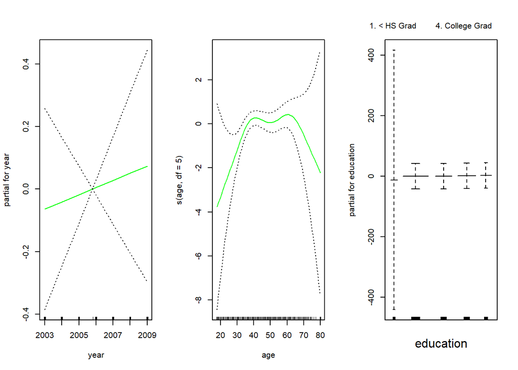

在右边第三幅图中，对于学历水平低于HS（high school，高中）的观测来说，误差很大，用table函数查看列联表，发现这个数据集中不存在低于高中学历的高收入人群，在这种情况下，可以在GAM模型中通过参数subset指定，在education对应的函数中不考虑高中以下学历的情况。

```
##
## education            FALSE TRUE
##   1. < HS Grad         268    0
##   2. HS Grad           966    5
##   3. Some College      643    7
##   4. College Grad      663   22
##   5. Advanced Degree   381   45
```

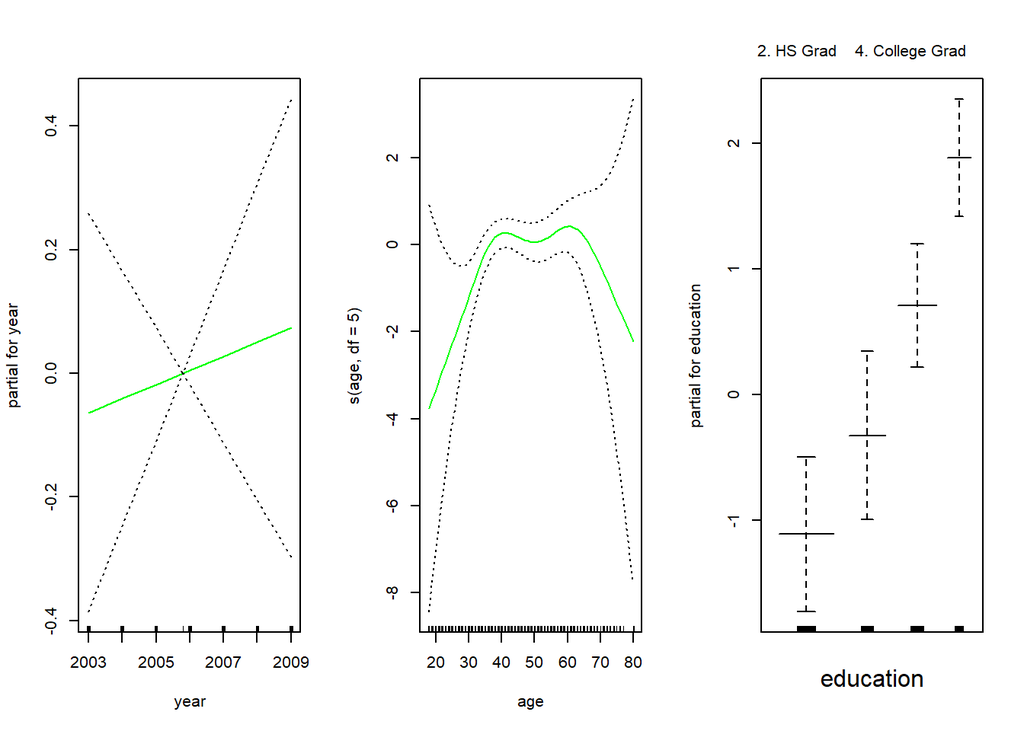